# Lab Assignment: Chapter 14 - Data Reshaping

Michael Beebe

```r
library(stringr)
library(plyr)
library(reshape2)
library(ggplot2)
library(scales)
```

## 1. cbind and rbind

Create 3 vectors: start, finish, and numeric

- The start vector has the first 10 capital letters of the alphabet
- The finish vector has the last 10 capital letters of the alphabet
- The numeric vector has the numbers 1-10

```r
start <- c("A", "B", "C", "D", "E", "F", "G", "H", "I", "J")
finish <- c("Q", "R", "S", "T", "U", "V", "W", "X", "Y", "Z")
numeric <- c(1:10)
```

Use cbind to bind these vectors into table1 by column

```r
table1 <- cbind(start, finish, numeric)
table1
```

```
##       start finish numeric
##  [1,] "A"   "Q"    "1"
##  [2,] "B"   "R"    "2"
##  [3,] "C"   "S"    "3"
##  [4,] "D"   "T"    "4"
##  [5,] "E"   "U"    "5"
##  [6,] "F"   "V"    "6"
##  [7,] "G"   "W"    "7"
##  [8,] "H"   "X"    "8"
##  [9,] "I"   "Y"    "9"
## [10,] "J"   "Z"    "10"
```

Use rbind to bind these vectors into table2 by row

```r
table2 <- rbind(start, finish, numeric)
table2
```

```
##         [,1] [,2] [,3] [,4] [,5] [,6] [,7] [,8] [,9] [,10]
## start   "A"  "B"  "C"  "D"  "E"  "F"  "G"  "H"  "I"  "J"
## finish  "Q"  "R"  "S"  "T"  "U"  "V"  "W"  "X"  "Y"  "Z"
## numeric "1"  "2"  "3"  "4"  "5"  "6"  "7"  "8"  "9"  "10"
```

Create 2 CSV files - data1.csv and data2.csv

- data1.csvshould have the column titles “Course” and “Title”  
  – List 7 courses and titles in the Data Analytics Degree
- data2.csv should have the column titles “Credits” and “Semester”  
  – List the credit hours and the semester you should take the courses in data1.csv

```r
# DFs THAT WE WILL USE TO MAKE THE CSVs
data1 <- data.frame(
  Course = c("ITCS 1010", "ITDB 1300", "ITDB 1400", "ITDB 1405", "ITCS 1880", "ITON 1205", "ITCS 1870"),
  Title = c("Programming Logic", "Intro to Database Theory", "Intro to SQL", "Oracle PL/SQL Programming", "R Programming", "Network+ and Networking Essentials", "Python Programming")
)

data2 <- data.frame(
  Credits = c(3, 3, 2, 2, 3, 3, 3),
  Semester = c(2, 2, 2, 2, 3, 3, 4)
)


# MAKING CSVs FROM DF
data1.csv <- write.csv(
  x = data1,
  file = "./Part1CSVs/data1.csv"
)

data2.csv <- write.csv(
  x = data2,
  file = "./Part1CSVs/data2.csv"
)
```

Import and use cbind to bind these 2 datasets together.

```r
data3.csv <- write.csv(
  x = cbind(data1, data2),
  file = "./Part1CSVs/data3.csv"
)
```

## 2. Joins

Unzip the US_Foreign_Aid.zip file into a directory on your computer

```r
foreign_aid <- unzip("../../Data/US_Foreign_Aid.zip", exdir = "./US_Foreign_Aid")
foreign_aid
```

```
## [1] "./US_Foreign_Aid/US_Foreign_Aid_40s.csv"
## [2] "./US_Foreign_Aid/US_Foreign_Aid_50s.csv"
## [3] "./US_Foreign_Aid/US_Foreign_Aid_60s.csv"
## [4] "./US_Foreign_Aid/US_Foreign_Aid_70s.csv"
## [5] "./US_Foreign_Aid/US_Foreign_Aid_80s.csv"
## [6] "./US_Foreign_Aid/US_Foreign_Aid_90s.csv"
## [7] "./US_Foreign_Aid/US_Foreign_Aid_00s.csv"
## [8] "./US_Foreign_Aid/US_Foreign_Aid_10s.csv"
```

```r
aid_data <- dir("US_Foreign_Aid/", pattern = "\\.csv")

for (i in aid_data) {
  us_foreign_aid <- str_sub(string = i, start=12, end=18)
  temp <- read.table(file = file.path("US_Foreign_Aid/", i),
                     header = TRUE, sep = ",", stringsAsFactors = FALSE)
  assign(x=us_foreign_aid, value = temp)
}
```

Merge the data from the 80s and 90s and display to the console

```r
aid80s90s <- merge(
  x = Aid_80s,
  y = Aid_90s,
  by.x = c("Country.Name", "Program.Name"),
  by.y = c("Country.Name", "Program.Name")
)

head(aid80s90s)
```

```
##   Country.Name                                      Program.Name FY1980 FY1981
## 1  Afghanistan                         Child Survival and Health     NA     NA
## 2  Afghanistan         Department of Defense Security Assistance     NA     NA
## 3  Afghanistan                            Development Assistance     NA     NA
## 4  Afghanistan Economic Support Fund/Security Support Assistance     NA     NA
## 5  Afghanistan                                Food For Education     NA     NA
## 6  Afghanistan                  Global Health and Child Survival     NA     NA
##   FY1982 FY1983 FY1984 FY1985 FY1986 FY1987 FY1988 FY1989 FY1990 FY1991 FY1992
## 1     NA     NA     NA     NA     NA     NA     NA     NA     NA     NA     NA
## 2     NA     NA     NA     NA     NA     NA     NA     NA     NA     NA     NA
## 3     NA     NA     NA     NA     NA     NA     NA     NA     NA     NA     NA
## 4     NA     NA     NA     NA     NA     NA     NA     NA     NA     NA     NA
## 5     NA     NA     NA     NA     NA     NA     NA     NA     NA     NA     NA
## 6     NA     NA     NA     NA     NA     NA     NA     NA     NA     NA     NA
##     FY1993  FY1994 FY1995 FY1996 FY1997 FY1998 FY1999
## 1       NA      NA     NA     NA     NA     NA     NA
## 2       NA      NA     NA     NA     NA     NA     NA
## 3       NA      NA     NA     NA     NA     NA     NA
## 4 14178135 2769948     NA     NA     NA     NA     NA
## 5       NA      NA     NA     NA     NA     NA     NA
## 6       NA      NA     NA     NA     NA     NA     NA
```

Merge the data from the 90s and 00s and display to the console

```r
aid90s00s <- merge(
  x = Aid_90s,
  y = Aid_00s,
  by.x = c("Country.Name", "Program.Name"),
  by.y = c("Country.Name", "Program.Name")
)

head(aid90s00s)
```

```
##   Country.Name                                      Program.Name FY1990 FY1991
## 1  Afghanistan                         Child Survival and Health     NA     NA
## 2  Afghanistan         Department of Defense Security Assistance     NA     NA
## 3  Afghanistan                            Development Assistance     NA     NA
## 4  Afghanistan Economic Support Fund/Security Support Assistance     NA     NA
## 5  Afghanistan                                Food For Education     NA     NA
## 6  Afghanistan                  Global Health and Child Survival     NA     NA
##   FY1992   FY1993  FY1994 FY1995 FY1996 FY1997 FY1998 FY1999 FY2000  FY2001
## 1     NA       NA      NA     NA     NA     NA     NA     NA     NA      NA
## 2     NA       NA      NA     NA     NA     NA     NA     NA     NA      NA
## 3     NA       NA      NA     NA     NA     NA     NA     NA     NA 4110478
## 4     NA 14178135 2769948     NA     NA     NA     NA     NA     NA   61144
## 5     NA       NA      NA     NA     NA     NA     NA     NA     NA      NA
## 6     NA       NA      NA     NA     NA     NA     NA     NA     NA      NA
##     FY2002    FY2003     FY2004     FY2005     FY2006     FY2007     FY2008
## 1  2586555  56501189   40215304   39817970   40856382   72527069   28397435
## 2  2964313        NA   45635526  151334908  230501318  214505892  495539084
## 3  8762080  54538965  180539337  193598227  212648440  173134034  150529862
## 4 31827014 341306822 1025522037 1157530168 1357750249 1266653993 1400237791
## 5       NA   3957312    2610006    3254408     386891         NA         NA
## 6       NA        NA         NA         NA         NA         NA   63064912
##       FY2009
## 1         NA
## 2  552524990
## 3    3675202
## 4 1418688520
## 5         NA
## 6    1764252
```

Use the plyr package and join function to do the same for both sets of data

```r
aid80s90s_join <- join(
  x = Aid_80s,
  y = Aid_90s,
  by = c("Country.Name", "Program.Name")
)

aid90s00s_join <- join(
  x = Aid_90s,
  y = Aid_00s,
  by = c("Country.Name", "Program.Name")
)
```

Combine the 8 foreign aid data frames into 1 data frame by putting them in a list and joining toghether

```r
df_names <-str_sub(string = aid_data, start = 12, end = 18)
df_list <- vector("list", length(df_names))
names(df_list) <- df_names
for (i in df_names) {
  df_list[[i]] <- eval(parse(text = i))
}

all_aid <- Reduce(function(...) {
  join(..., by = c("Country.Name", "Program.Name"))
}, df_list)

dim(all_aid)
```

```
## [1] 2453   67
```

## 3. reshape2

Use melt so that each row represents a Country-Program-Year entry with Dollars stored in a column

```r
aid_melt <- melt(
  data = all_aid,
  id.vars = c("Country.Name", "Program.Name"),
  variable.name = "Year",
  value.name = "Dollars"
)

aid_melt$Year <- as.numeric(str_sub(aid_melt$Year, start = 3, end = 6))

tail(aid_melt)
```

```
##        Country.Name            Program.Name Year  Dollars
## 159440     Zimbabwe Other Food Aid Programs 1999  1645691
## 159441     Zimbabwe  Other State Assistance 1999   191624
## 159442     Zimbabwe  Other USAID Assistance 1999   155788
## 159443     Zimbabwe             Peace Corps 1999  2075542
## 159444     Zimbabwe                 Title I 1999 12764713
## 159445     Zimbabwe                Title II 1999       NA
```

Aggregate and plot the data

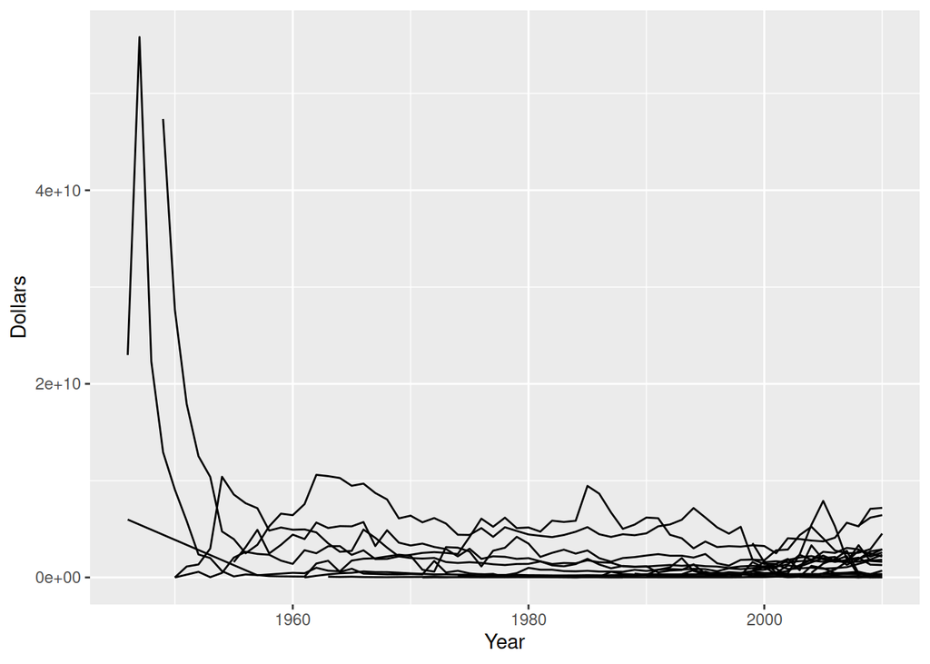

```r
melt_agg <- aggregate(
  Dollars ~ Program.Name + Year,
  data = aid_melt,
  FUN = sum,
  na.rm = TRUE
)

melt_agg$Program.Name <- str_sub(melt_agg$Program.Name, start = 1, end = 10)

ggplot(melt_agg, aes(x=Year, y=Dollars)) +
  geom_line(aes(group=Program.Name))
```